# Multifactor Productivity Forecasting

Here’s the autocorrelation function (ACF): notice the blue lines? Those are the significance bounds. Autocorrelations outside those are very probably different from zero (e.g. not chance).

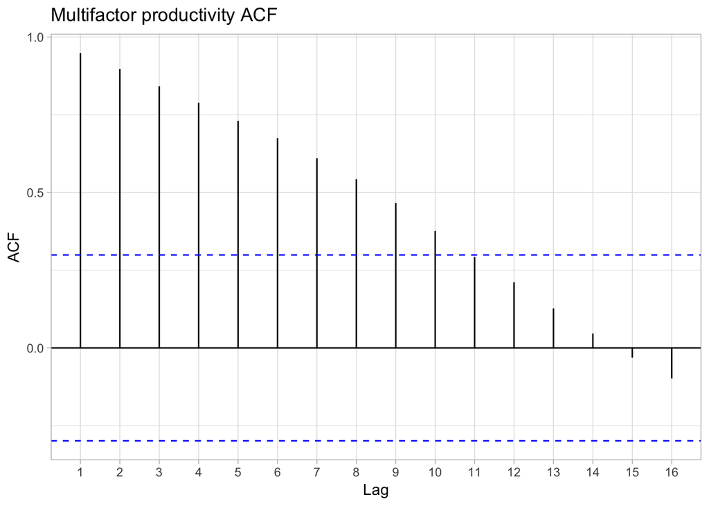

```r
ggAcf(productivity[,4]) +
  ggtitle("Multifactor productivity ACF")+
  theme_light()
```

Next up the partial autocorrelation function (PACF). One ‘blip’ in the first lag that is significant and nothing much after. Combined with a long slow decay in the ACF - this means high levels of a first order autoregression in most cases, but not much in the way of moving average components, most likely.

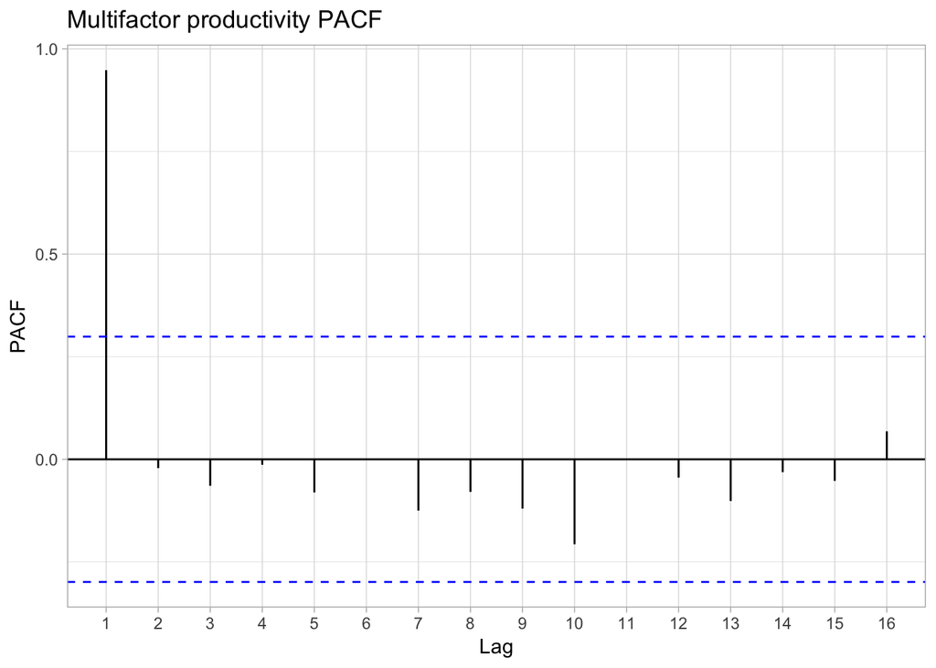

```r
ggPacf(productivity[,4]) +
  ggtitle("Multifactor productivity PACF")+
  theme_light()
```

# A simple forecast

The `forecast` package provides some very simple tools for producing forecasts. What we can see from our plots above, though, is pretty consistent with common sense:

[output not shown]

How can we tell if we’re dealing with a nonstationary time series? The package `tseries` has some useful functions. The `adf.test()` function uses the Augmented Dickey Fuller (Said and Dickey 1984) test for a null hypothesis of a unit root, while the `kpss.test()` function tests for a null hypothesis of stationarity (Kwiatkowski, Phillips, Schmidt and Shin 1992). If these two tests produce different outcomes (e.g. one rejects the null, the other does not) - they’re in agreement. In practice, these tests tend to come with lower power as it’s an absolute bastard of a parameter space to be working in, asymptotically speaking. (That’s a technical term from someone who wrote a Ph.D. on panel unit root tests.)

The `ndiffs()` function is from the `forecast` package and suggests a number of differences required to achieve stationarity.

```r
library(tseries)
adf.test(productivity[,4], alternative = "stationary")
```

```
##
##  Augmented Dickey-Fuller Test
##
## data:  productivity[, 4]
## Dickey-Fuller = -2.391, Lag order = 3, p-value = 0.4193
## alternative hypothesis: stationary
```

```r
kpss.test(productivity[,4])
```

```
##
##  KPSS Test for Level Stationarity
##
## data:  productivity[, 4]
## KPSS Level = 2.1496, Truncation lag parameter = 1, p-value = 0.01
```

```r
ndiffs(productivity[,4])
```

```
## [1] 1
```

Here the ADF test does not reject the null hypothesis of a unit root, while the KPSS test rejects the null hypothesis of stationarity while `ndiffs()` suggests a single differencing is required. It’s all in agreement there.

# Let’s try a model with these properties

This isn’t my ‘modelling process’ - truth is, I’ve tried a bunch of different models on this data and here’s what I’m after for it:

```
* I want a three-piece trend
* I'd like to include the labour and capital indices as regressors, but I'll be predicting those as well for the final product
* There is an ARIMA(1,1,0) here by my best judgement and I'd like regression errors to suit.
```

Here’s my basic model without the ARIMA components: not bad, a little overeactive at times.

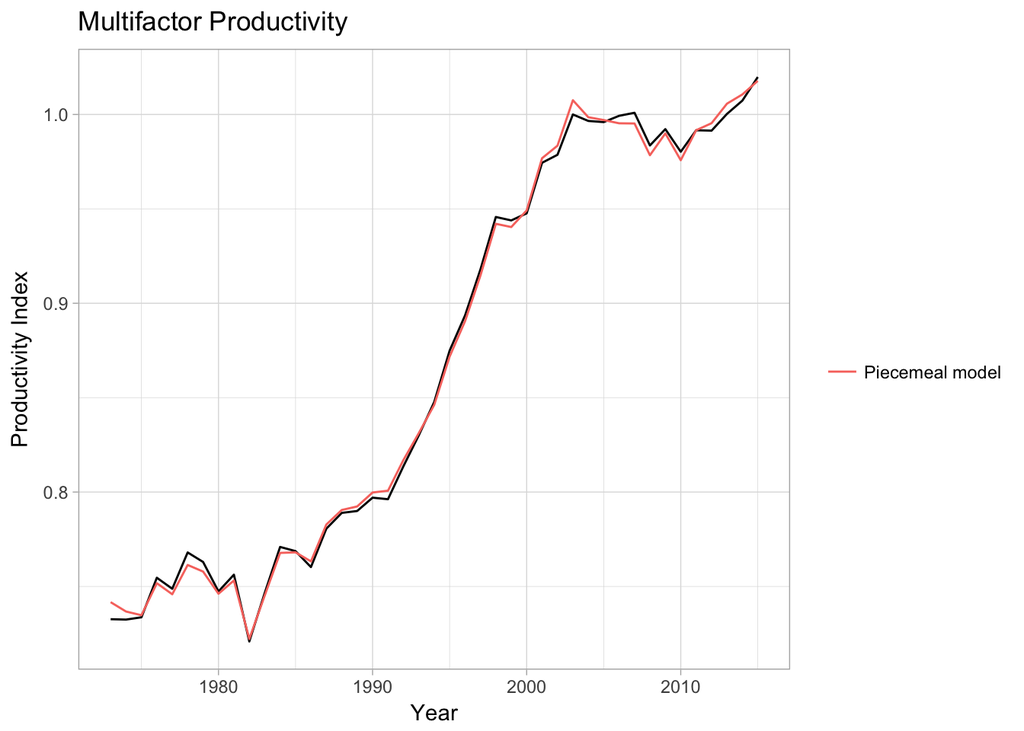

```r
# Trend terms
t <- time(productivity)
break1 <- 1987
break2 <-2003
t1 <- ts(pmax(0, t - break1), start = 1973)
t2 <- ts(pmax(0, t - break2), start = 1973)

fit.pm <- tslm(productivity[,4] ~ t + t1 + t2 + Capital + LabourHW, data=productivity)

autoplot(productivity[,4]) +
  autolayer(fitted(fit.pm), series = "Piecemeal model") +
  xlab("Year") +  ylab("Productivity Index") +
  ggtitle("Multifactor Productivity") +
  guides(colour=guide_legend(title=" ")) +
  theme_light()
```

If we check the residuals, we can see a whole bunch of autocorrelation simply not been dealt with. We need to deal!

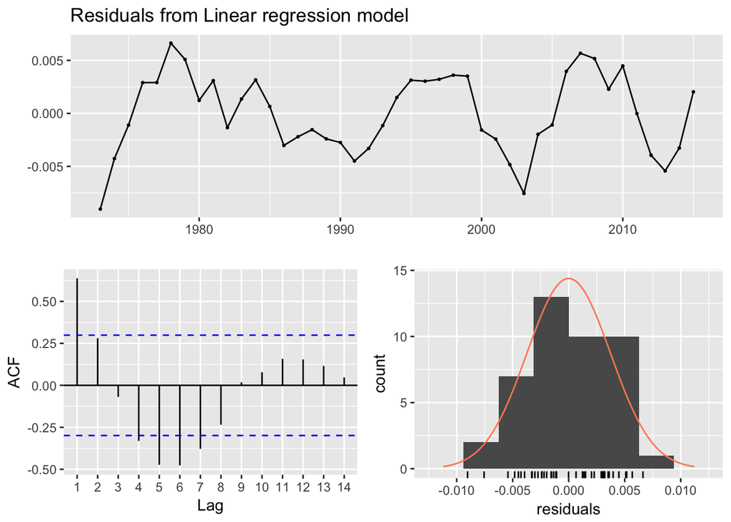

```
##
##  Breusch-Godfrey test for serial correlation of order up to 10
##
## data:  Residuals from Linear regression model
## LM test = 30.341, df = 10, p-value = 0.0007533
```

```r
checkresiduals(fit.pm)
```

Here’s what happen if we add a ARIMA(1,1,0) innovations to the mix:

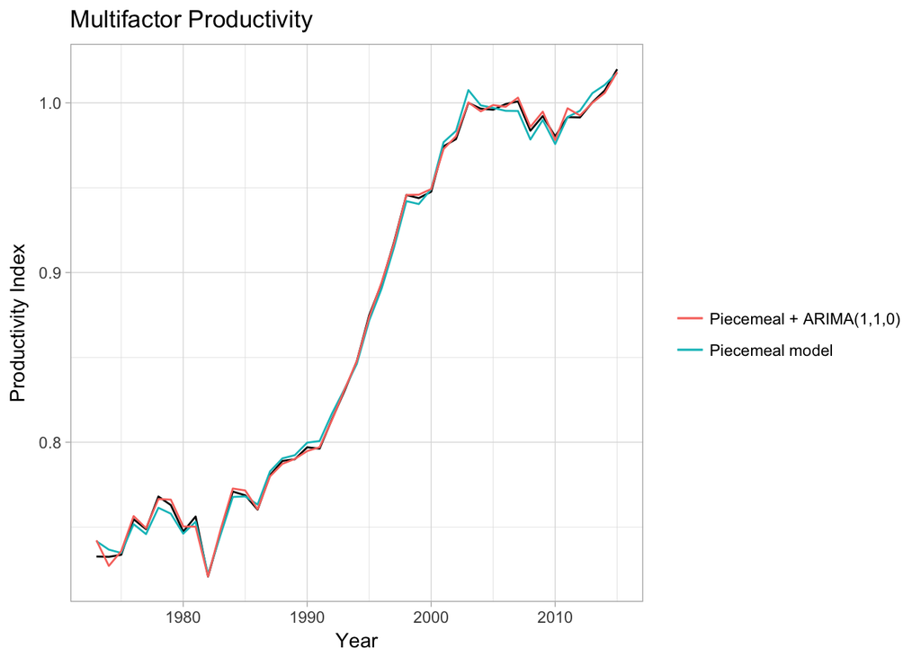

```r
fit <- Arima(productivity[,4], order = c(1,1,0),
            xreg=cbind(productivity[,c(1,3)], t, t1, t2))

autoplot(productivity[,4]) +
  autolayer(fitted(fit.pm), series = "Piecemeal model") +
  autolayer(fitted(fit), series = "Piecemeal + ARIMA(1,1,0)")+
  xlab("Year") +  ylab("Productivity Index") +
  ggtitle("Multifactor Productivity") +
  guides(colour=guide_legend(title=" ")) +
  theme_light()
```

This is looking much better- checking residuals: a little skewed maybe, but still significant autocorrelation left in the model.

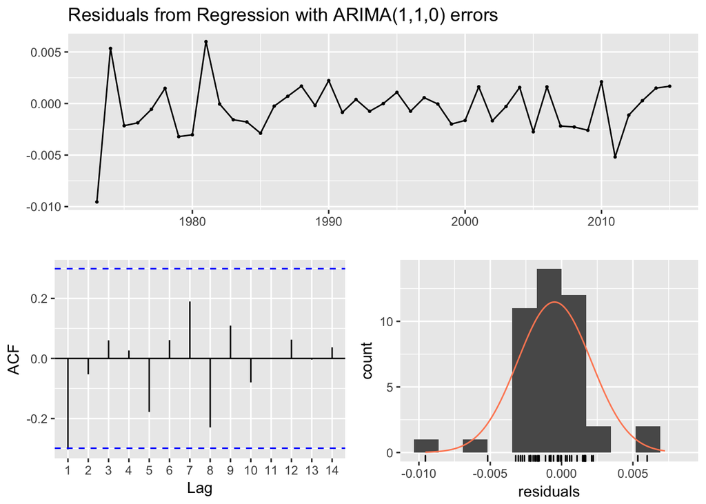

```
##
##  Ljung-Box test
##
## data:  Residuals from Regression with ARIMA(1,1,0) errors
## Q* = 12.273, df = 4, p-value = 0.01544
##
## Model df: 6.   Total lags used: 10
```

```r
checkresiduals(fit)
```

The problem here, I reckon, is the three piece trend I was so fond of - that’s in both the regressors: labour and capital so it’s probably overfitting. Let’s jettison that and use just the regressors and let an integrated AR process mop up the trend stochastically.

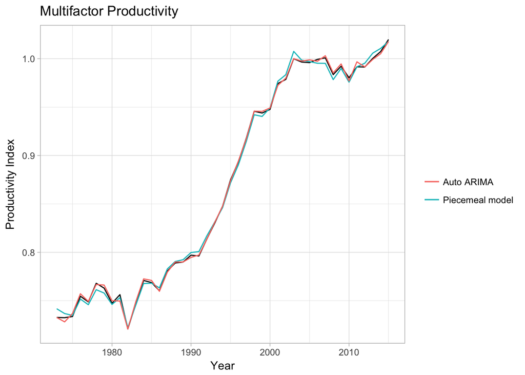

```r
fit <- Arima(productivity[,4], order = c(1,1,0),
            xreg=cbind(productivity[,c(1,3)]))

autoplot(productivity[,4]) +
  autolayer(fitted(fit.pm), series = "Piecemeal model") +
  autolayer(fitted(fit), series = "Auto ARIMA")+
  xlab("Year") +  ylab("Productivity Index") +
  ggtitle("Multifactor Productivity") +
  guides(colour=guide_legend(title=" ")) +
  theme_light()
```

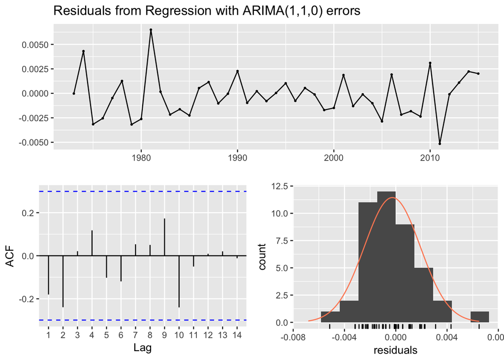

```
##
##  Ljung-Box test
##
## data:  Residuals from Regression with ARIMA(1,1,0) errors
## Q* = 11.551, df = 7, p-value = 0.1163
##
## Model df: 3.   Total lags used: 10
```

```r
checkresiduals(fit)
```

Bingo! No more autocorrelation in the residuals. Let that be a lesson to me forever and ever about over fitting.

# Now we want to forecast multifactor productivity

Now to make a forecast. To do that in this model, we need to forecast capital and labour productivity first. Unsurprisingly, capital and labour productivity have similar time series components to multifactor productivity, so I’ll model them both as ARIMA(1,1,0) plus trends. Without the other regressors that multifactor productivity had, we need those trends this time.

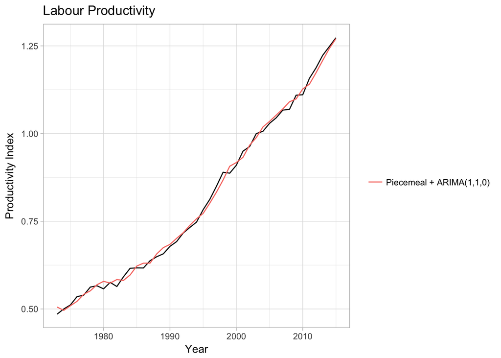

```r
fit.labour <- Arima(productivity[,1], order = c(1,1,0),
                    xreg = cbind(t, t1, t2))

autoplot(productivity[,1]) +
  autolayer(fitted(fit.labour), series = "Piecemeal + ARIMA(1,1,0)")+
  xlab("Year") +  ylab("Productivity Index") +
  ggtitle("Labour Productivity") +
  guides(colour=guide_legend(title=" ")) +
  theme_light()
```

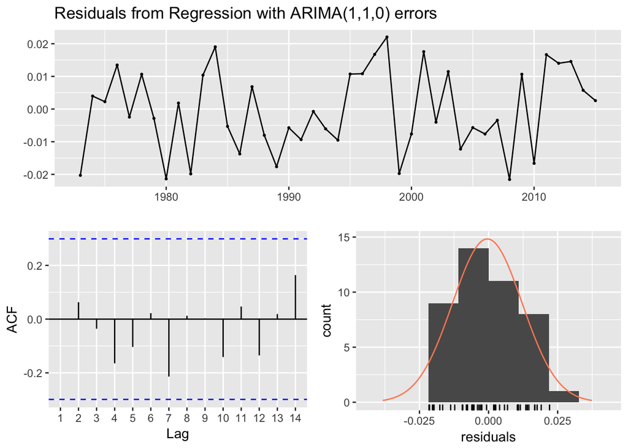

```
##
##  Ljung-Box test
##
## data:  Residuals from Regression with ARIMA(1,1,0) errors
## Q* = 5.7964, df = 6, p-value = 0.4464
##
## Model df: 4.   Total lags used: 10
```

```r
checkresiduals(fit.labour)
```

Neither is as good as when you’ve got regressors to work with, but OK this will do.

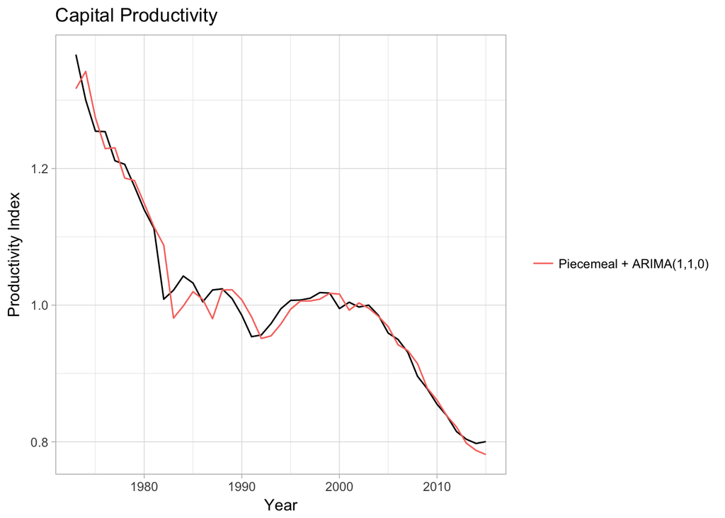

```r
fit.capital <- Arima(productivity[,3], order = c(1,1,0),
                    xreg = cbind(t, t1, t2))

autoplot(productivity[,3]) +
  autolayer(fitted(fit.capital), series = "Piecemeal + ARIMA(1,1,0)")+
  xlab("Year") +  ylab("Productivity Index") +
  ggtitle("Capital Productivity") +
  guides(colour=guide_legend(title=" ")) +
  theme_light()
```

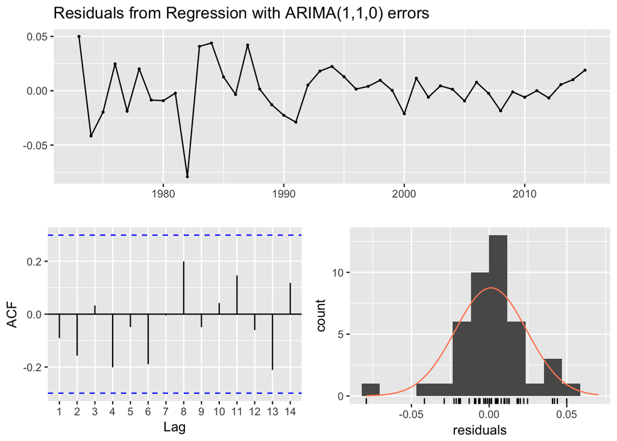

```
##
##  Ljung-Box test
##
## data:  Residuals from Regression with ARIMA(1,1,0) errors
## Q* = 8.0429, df = 6, p-value = 0.235
##
## Model df: 4.   Total lags used: 10
```

```r
checkresiduals(fit.capital)
```

Now, I need to choose a time horizon to forecast capital and labour productivity over. I’m going to go with h = 5 periods, not because I care about periods 2-5, but because it’s useful to see how the series is tracking.

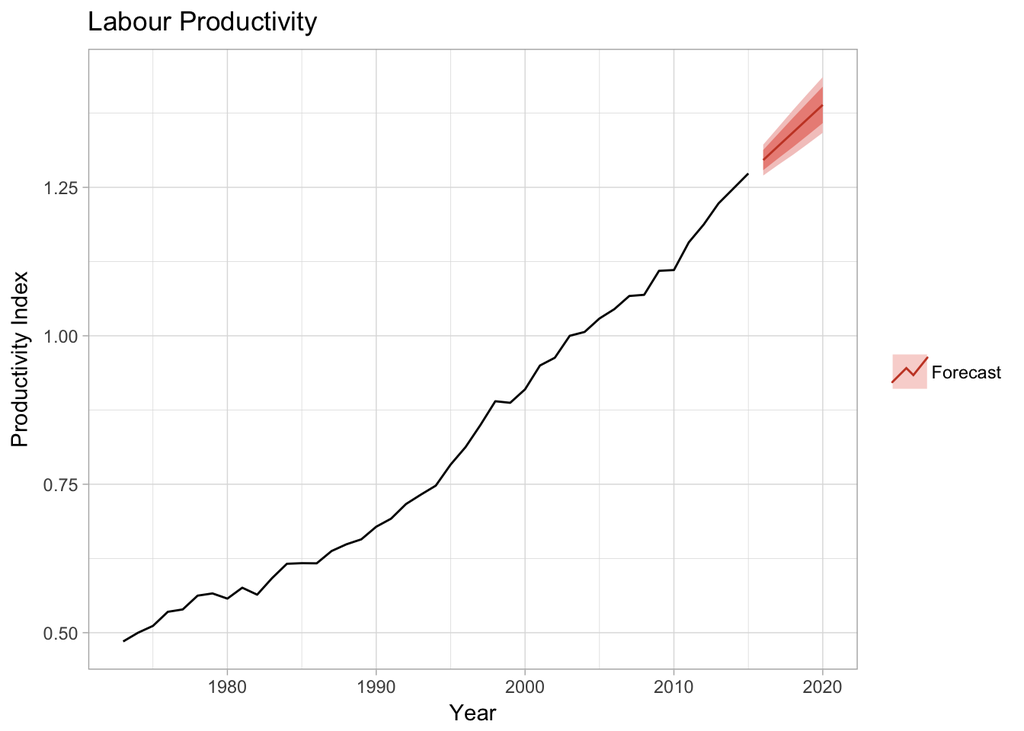

```r
h <- 5
t.new <- t[length(t)]+seq(h)
t1.new <- t1[length(t1)]+seq(h)
t2.new <- t2[length(t2)]+seq(h)
trend.terms <- (cbind(t.new, t1.new, t2.new))

fcast.labour <- forecast(fit.labour, h = 5, xreg = trend.terms)

autoplot(productivity[,1]) +
  autolayer((fcast.labour), PI = TRUE, series = "Forecast")+
  xlab("Year") +  ylab("Productivity Index") +
  ggtitle("Labour Productivity") +
  guides(colour=guide_legend(title=" ")) +
  theme_light()
```

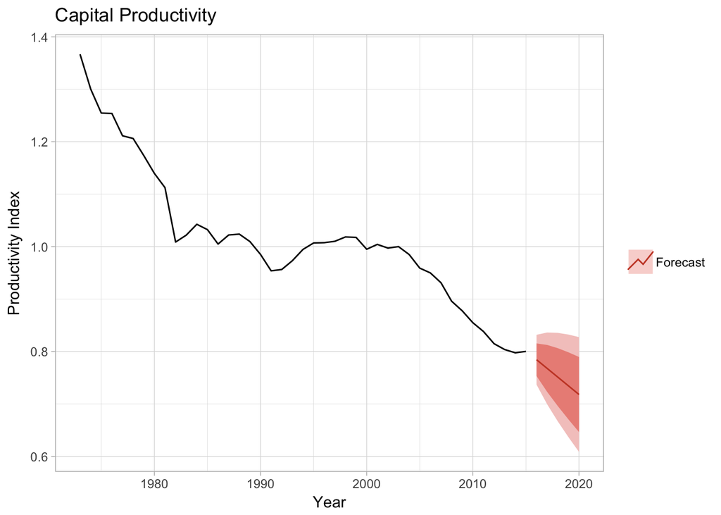

```r
fcast.capital <- forecast(fit.capital, h = 5, xreg = trend.terms)

autoplot(productivity[,3]) +
  autolayer((fcast.capital), PI = TRUE, series = "Forecast")+
  xlab("Year") +  ylab("Productivity Index") +
  ggtitle("Capital Productivity") +
  guides(colour=guide_legend(title=" ")) +
  theme_light()
```

We can use the point forecasts for labour and capital to forecast multifactor productivity.

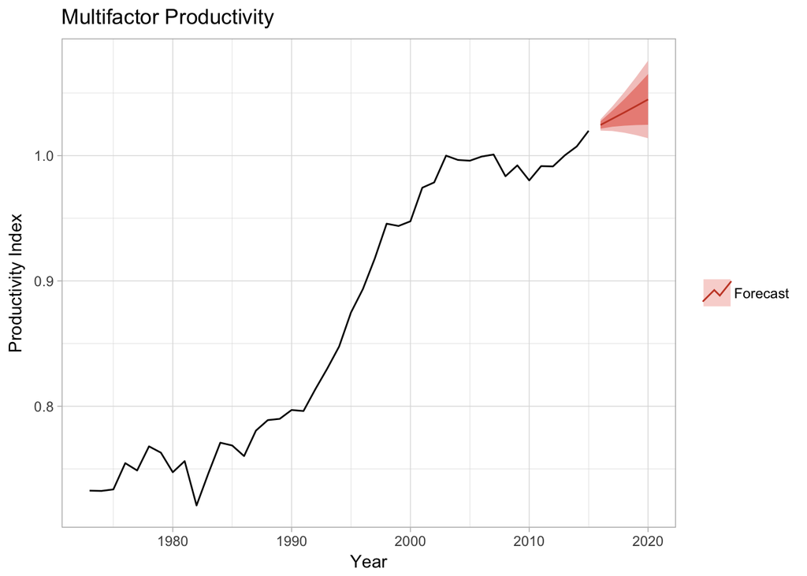

```r
l.fcast <- fcast.labour$mean
c.fcast <- fcast.capital$mean
regressorsMFP <- cbind(l.fcast, c.fcast)

fcast.MFP <- forecast(fit, h = 5, xreg = regressorsMFP)

autoplot(productivity[,4]) +
  autolayer((fcast.MFP), PI = TRUE, series = "Forecast")+
  xlab("Year") +  ylab("Productivity Index") +
  ggtitle("Multifactor Productivity") +
  guides(colour=guide_legend(title=" ")) +
  theme_light()
```

So my rough forecast for multifactor productivity (which is admittedly rather overfitted with that piecemeal trend - OK! OK!) is around 1.02- more or less.

Let’s see what the ABS comes up with. But it’s also [worthwhile being aware just what a brutally difficult issue this is](https://ftalphaville.ft.com/2017/11/24/2196134/the-obrs-productivity-forecast/).

# References

Australian Bureau of Statistics (2016) Estimates of Industry Multifactor Productivity, Australia (series 5260.0.55.002)](http://www.abs.gov.au/AUSSTATS/abs@.nsf/DetailsPage/5260.0.55.0022015-16?OpenDocument), released on December 5, 2016. Accessed 05/12/16.

Hyndman RJ (2017). *forecast: Forecasting functions for time series and linear models*. R package version 8.2, <URL: http://pkg.robjhyndman.com/forecast>.

Hyndman RJ and Khandakar Y (2008). “Automatic time series forecasting: the forecast package for R.” *Journal of Statistical Software*, *26*(3), pp. 1-22. <URL: http://www.jstatsoft.org/article/view/v027i03>.

D. Kwiatkowski, P. C. B. Phillips, P. Schmidt, and Y. Shin (1992): Testing the Null Hypothesis of Stationarity against the Alternative of a Unit Root. Journal of Econometrics 54, 159–178.

S. E. Said and D. A. Dickey (1984): Testing for Unit Roots in Autoregressive-Moving Average Models of Unknown Order. Biometrika 71, 599–607.

Adrian Trapletti and Kurt Hornik (2017). tseries: Time Series Analysis and Computational Finance. R package version 0.10-42.

Hadley Wickham (2017). tidyverse: Easily Install and Load ‘Tidyverse’ Packages. R package version 1.1.1. https://CRAN.R-project.org/package=tidyverse